# PUBG Match Deaths

Jinqian Pan

11/1/2018

# Introduction

Video games are a rich area for data extraction due to its digital nature. Notable examples such as the complex EVE Online economy, World of Warcraft corrupted blood incident and even Grand Theft Auto self-driving cars tells us that fiction is closer to reality than we really think. Data scientists can gain insight on the logic and decision-making that the players face when put in hypothetical and virtual scenarios.

In this Kaggle Dataset, I provide over 720,000 competitive matches from the popular game PlayerUnknown’s Battlegrounds. The data was extracted from pubg.op.gg, a game tracker website. I intend for this data-set to be purely exploratory, however users are free to create their own predictive models they see fit.

https://www.kaggle.com/skihikingkevin/pubg-match-deaths/home

## Reading Data

```r
# pubg_match_deaths <- read.csv("/Users/jinqian_pan/Desktop/MATH3700/bigdata2018/projects/pubg-match-deaths/aggregate/agg_match_stats_0.csv")
# save(pubg_match_deaths, file = '/Users/jinqian_pan/Desktop/MATH3700/bigdata2018/projects/pubg-match-deaths/aggregate/agg_match_stats_0.Rdata')

pubg <- load('/Users/jinqian_pan/Desktop/MATH3700/bigdata2018/projects/pubg-match-deaths/aggregate/agg_match_stats_0.Rdata')
```

## Library

```r
library(dplyr)
library(tidyverse)
```

# Variable definitions

```r
str(pubg_match_deaths)
```

```
## 'data.frame':    13849287 obs. of  15 variables:
##  $ date               : Factor w/ 148334 levels "2017-10-20T08:01:47+0000",..: 63065 63065 63065 63065 63065 63065 63065 63065 63065 63065 ...
##  $ game_size          : int  37 37 37 37 37 37 37 37 37 37 ...
##  $ match_id           : Factor w/ 149994 levels "2U4GBNA0Ymk__2tOUiCwtY26m3lIEbGqEZE-M13dPb-tEROsU8hUQwUkBHsVijQa",..: 135914 135914 135914 135914 135914 135914 135914 135914 135914 135914 ...
##  $ match_mode         : Factor w/ 1 level "tpp": 1 1 1 1 1 1 1 1 1 1 ...
##  $ party_size         : int  2 2 2 2 2 2 2 2 2 2 ...
##  $ player_assists     : int  0 0 0 0 0 0 0 0 0 0 ...
##  $ player_dbno        : int  1 1 0 0 0 0 0 0 0 1 ...
##  $ player_dist_ride   : num  2871 2938 0 0 2619 ...
##  $ player_dist_walk   : num  1784.8 1756.1 224.2 92.9 2510.4 ...
##  $ player_dmg         : int  117 127 67 0 175 65 0 0 79 101 ...
##  $ player_kills       : int  1 1 0 0 2 0 0 0 0 1 ...
##  $ player_name        : Factor w/ 4269508 levels "","0___bin___0",..: 3210270 2690654 522716 3036141 1321401 233875 2883743 1114661 2963702 3230254 ...
##  $ player_survive_time: num  1106 1106 236 198 1537 ...
##  $ team_id            : int  4 4 5 5 14 14 15 15 17 17 ...
##  $ team_placement     : int  18 18 33 33 11 11 17 17 24 24 ...
```

In this dataset, I have “date”, “game size”, “match id”, and so on. Some of these data are useless, such as “date”, “team id”. I can find anything, because PUBG is a game.

## Choose data

```r
pubg_using_data <- as.data.frame(cbind(pubg_match_deaths$game_size, pubg_match_deaths$party_size, pubg_match_deaths$player_dist_ride, pubg_match_deaths$player_dist_walk, pubg_match_deaths$player_dmg, pubg_match_deaths$player_kills, pubg_match_deaths$player_survive_time))

names(pubg_using_data) <- c("game size", "party size", "player distance ride", "player distance walk", "player damage", "player kills", "player survive time")

str(pubg_using_data)
```

```
## 'data.frame':    13849287 obs. of  7 variables:
##  $ game size           : num  37 37 37 37 37 37 37 37 37 37 ...
##  $ party size          : num  2 2 2 2 2 2 2 2 2 2 ...
##  $ player distance ride: num  2871 2938 0 0 2619 ...
##  $ player distance walk: num  1784.8 1756.1 224.2 92.9 2510.4 ...
##  $ player damage       : num  117 127 67 0 175 65 0 0 79 101 ...
##  $ player kills        : num  1 1 0 0 2 0 0 0 0 1 ...
##  $ player survive time : num  1106 1106 236 198 1537 ...
```

# Data Cleaning

```r
summary(pubg_using_data$`player survive time`)
```

```
##      Min.   1st Qu.    Median      Mean   3rd Qu.      Max.
## 0.000e+00 2.470e+02 6.530e+02 8.351e+04 1.299e+03 6.365e+10
```

```r
pubg_sub <- filter(pubg_using_data, pubg_using_data$`player survive time` < 2500)

pubg_party_size <- as.factor(pubg_sub$`party size`)
str(pubg_party_size)
```

```
##  Factor w/ 3 levels "1","2","4": 2 2 2 2 2 2 2 2 2 2 ...
```

```r
level <- c("SOLO", "Duo", "Squad")
levels(pubg_party_size) <- level
str(pubg_party_size)
```

```
##  Factor w/ 3 levels "SOLO","Duo","Squad": 2 2 2 2 2 2 2 2 2 2 ...
```

# Explore the data

## The Time of Game - box plot

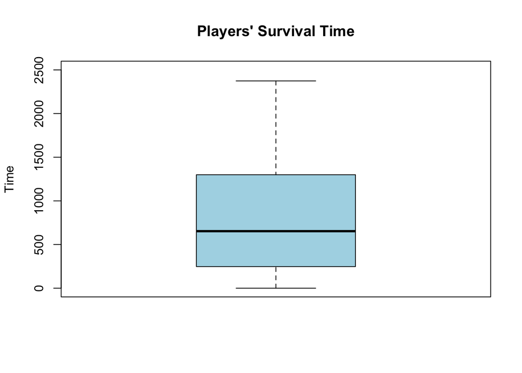

```r
boxplot(pubg_sub$`player survive time`, col = "lightblue", main = "Players' Survival Time" , ylim = c(0, 2500), ylab =  "Time")
```

## Player Kills - histogram

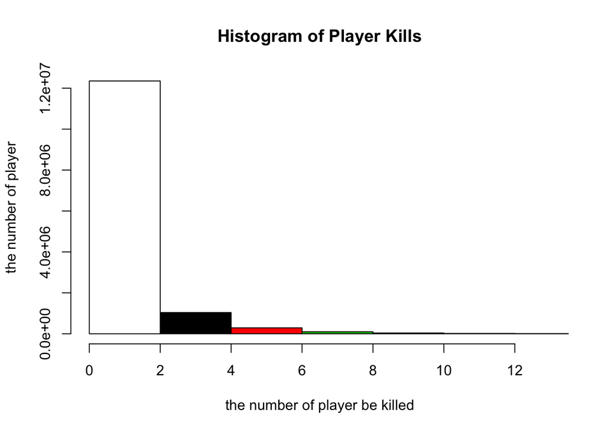

```r
hist(pubg_sub$`player kills`, xlim = c(0,13), col = 0:15, ylab = "the number of player", xlab = "the number of player be killed", main = "Histogram of Player Kills")
```